# Data 621 - Blog 5

Leticia Salazar

December 8, 2022

$~$

## Non-parametric test - Wilcoxon Signed Rank:

For this final blog I decided to dig more into non-parametric tests that was mentioned in the weekly video for the class. Non-parametric tests is a method of statistical analysis that does not require a normally distributed data. It serves an alternative to parametric tests such as T-test or ANOVA.

$~$

When to use non-parametric tests?:

- When your data isn’t normally distributed
- For nominal scales or ordinal scales
- One or more assumptions of parametric tests have been violated
- Your sample size is too small to run parametric test
- Your data has outliers that cannot be removed
- You want to test for the median rather than the mean (very skewed distribution)

$~$

The main nonparametric tests are:

- 1-sample sign test. Use this test to estimate the median of a population and compare it to a reference value or target value.
- 1-sample Wilcoxon signed rank test. With this test, you also estimate the population median and compare it to a reference/target value. However, the test assumes your data comes from a symmetric distribution (like the Cauchy distribution or uniform distribution).
- Friedman test. This test is used to test for differences between groups with ordinal dependent variables. It can also be used for continuous data if the one-way ANOVA with repeated measures is inappropriate (i.e. some assumption has been violated).
- Goodman Kruska’s Gamma: a test of association for ranked variables.
- Kruskal-Wallis test. Use this test instead of a one-way ANOVA to find out if two or more medians are different. Ranks of the data points are used for the calculations, rather than the data points themselves.
- The Mann-Kendall Trend Test looks for trends in time-series data.
- Mann-Whitney test. Use this test to compare differences between two independent groups when dependent variables are either ordinal or continuous.
- Mood’s Median test. Use this test instead of the sign test when you have two independent samples.
- Spearman Rank Correlation.Use when you want to find a correlation between two sets of data.

$~$

There can be some disadvantages to non-parametric tests:

- Less powerful than parametric tests if assumptions haven’t been violated.
- More labor-intensive to calculate by hand (for computer calculations, this isn’t an issue).
- Critical value tables for many tests aren’t included in many computer software packages. This is compared to tables for parametric tests (like the z-table or t-table) which usually are included.

Lets put one of these non-parametric tests to the test in R. I will be using the 1-sample Wilcoxon signed rank test.

### Load libraries

Below is the libraries used for this case:

```r
library(stats) # wilcox.test()
library(ggplot2)
library(hrbrthemes)
```

We first create our values to use and then using the `wilcox.test()` we can start testing.

To check if we can reject our null or alternate hypotheses our significance level alpha must be less than 0.05.

$~$

Other parameters:

- x: a numeric vector containing your data values
- mu: the theoretical mean/median value. Default is 0 but you can change it.
- alternative: the alternative hypothesis. Allowed value is one of “two.sided” (default), “greater” or “less”.

$~$

### Load data:

```r
# The data set
set.seed(1234)
myData = data.frame(
name = paste0(rep("R_", 10), 1:10),
weight = round(rnorm(10, 30, 2), 1)
)

# Print the data
myData
```

```
##    name weight
## 1   R_1   27.6
## 2   R_2   30.6
## 3   R_3   32.2
## 4   R_4   25.3
## 5   R_5   30.9
## 6   R_6   31.0
## 7   R_7   28.9
## 8   R_8   28.9
## 9   R_9   28.9
## 10 R_10   28.2
```

$~$

The distribution:

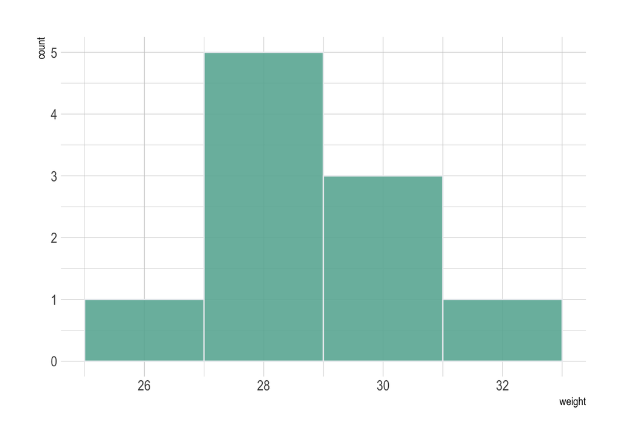

```r
ggplot(myData, aes(x=weight)) +
  geom_histogram(binwidth=2, fill="#69b3a2", color="#e9ecef", alpha=0.9) +
  theme_ipsum()
```

$~$

### Perform test:

```r
# One-sample wilcoxon test 1
wilcox.test(myData$weight, mu = 25)
```

```
##
##  Wilcoxon signed rank test with continuity correction
##
## data:  myData$weight
## V = 55, p-value = 0.005793
## alternative hypothesis: true location is not equal to 25
```

```r
# One-sample wilcoxon test 2
wilcox.test(myData$weight, mu = 25,
            alternative = "less") # testing if the median is less than 25
```

```
##
##  Wilcoxon signed rank test with continuity correction
##
## data:  myData$weight
## V = 55, p-value = 0.9979
## alternative hypothesis: true location is less than 25
```

```r
# One-sample wilcoxon test 3
wilcox.test(myData$weight, mu = 25,
            alternative = "greater") # testing if the median is greater than 25
```

```
##
##  Wilcoxon signed rank test with continuity correction
##
## data:  myData$weight
## V = 55, p-value = 0.002897
## alternative hypothesis: true location is greater than 25
```

$~$

After creating 3 different tests we notice the following:

- test 1 has a p-value of 0.005793 which is less than the significance level alpha of 0.05 therefore, we safely reject the null hypothesis.
- test 2 has a p-value of 0.9979 which is more than the significance level alpha of 0.05 therefore, we cannot reject the null hypothesis.
- test 3 has a p-value of 0.002897 which is less than the significance level alpha of 0.05 therefore, we can safely reject the null hypothesis.

$~$

### References:

- Non parametric data and tests (distribution free tests). Statistics How To. (2021, May 31). Retrieved November 26, 2022, from https://www.statisticshowto.com/probability-and-statistics/statistics-definitions/parametric-and-non-parametric-data/
- Glen, S. (n.d.). Wilcoxon signed rank test: Definition, how to run, SPSS. Statistics How To. Retrieved December 8, 2022, from https://www.statisticshowto.com/probability-and-statistics/statistics-definitions/wilcoxon-signed-rank-test/
- Rout, A. R. (2021, December 23). Wilcoxon signed rank test in R programming. GeeksforGeeks. Retrieved December 8, 2022, from https://www.geeksforgeeks.org/wilcoxon-signed-rank-test-in-r-programming/
- Mangiafico., S. S. (2015). Wilcoxon signed-rank test. R Companion: Wilcoxon Signed-rank Test. Retrieved December 8, 2022, from http://rcompanion.org/rcompanion/d_10.html
- Wilcoxon signed rank test in R programming. GeeksforGeeks. (2021, December 23). Retrieved December 8, 2022, from https://www.geeksforgeeks.org/wilcoxon-signed-rank-test-in-r-programming/